# Logistic Regression

Yi Zheng

November 16, 2015

In this study, we are interested the dependence of the probability that a person has positive self-esteem on some of the variables we are interested in. We will try to obtain a classification using the variables of interest to see which one or ones will predict whether a person has positive self-esteem most accurately.

First of all, we will construct a new binary variable named “Esteem” which takes the value 1 for strong agreement that “I feel I am a person of worth” and 0 for agreement, disagreement, or strong disagreement. We will also do log transformation on variable “income2005”. Since there’s no missing value in the data set, we don’t have to worry about the imputation.

```r
library(Sleuth3)
esdata <- ex1223
esdata$Esteem <- rep(0,nrow(esdata))
for (i in 1:nrow(esdata))
{
  if (esdata$Esteem1[i]==1) esdata$Esteem[i]=1
  else esdata$Esteem[i]==0
}
esdata$Esteem <- as.factor(esdata$Esteem)
esdata$LIncome2005 <- log(esdata$Income2005)
```

Now we need to divide the data into test and training data sets. We will create a new column called “train” and assign 1 or 0 in 80/20 proportion via random uniform distribution. In order to make the study reproducible, we need to set the random seed. Then we do data partition and create two data sets called “trainesdata” and “testesdata”. By viewing the distribution of gender in both data sets, we think both data sets are randomly created with no cluster effect.

```r
set.seed(6306)
esdata[,'train'] <- ifelse(runif(nrow(esdata))<0.80,1,0)
trainColNum <- grep('train',names(esdata))
trainesdata <- esdata[esdata$train==1,-trainColNum]
summary(trainesdata$Gender)
```

```
## female   male
##   1026   1043
```

```r
testesdata <- esdata[esdata$train==0,-trainColNum]
summary(testesdata$Gender)
```

```
## female   male
##    252    263
```

We include all the variables of interest to perform an logistic regression using the training data.

```r
esglm <- glm(Esteem~LIncome2005+AFQT+Educ+Gender,family = binomial(logit) ,data = trainesdata)
summary(esglm)
```

```
##
## Call:
## glm(formula = Esteem ~ LIncome2005 + AFQT + Educ + Gender, family = binomial(logit),
##     data = trainesdata)
##
## Deviance Residuals:
##     Min       1Q   Median       3Q      Max
## -1.7488  -1.2292   0.8342   1.0461   1.5694
##
## Coefficients:
##              Estimate Std. Error z value Pr(>|z|)
## (Intercept) -2.489377   0.543150  -4.583 4.58e-06 ***
## LIncome2005  0.141898   0.052517   2.702 0.006894 **
## AFQT         0.006814   0.002045   3.332 0.000864 ***
## Educ         0.075961   0.023464   3.237 0.001207 **
## Gendermale  -0.133583   0.096986  -1.377 0.168408
## ---
## Signif. codes:  0 '***' 0.001 '**' 0.01 '*' 0.05 '.' 0.1 ' ' 1
##
## (Dispersion parameter for binomial family taken to be 1)
##
##     Null deviance: 2812.4  on 2068  degrees of freedom
## Residual deviance: 2734.8  on 2064  degrees of freedom
## AIC: 2744.8
##
## Number of Fisher Scoring iterations: 4
```

```r
exp(cbind(OR = coef(esglm), confint(esglm)))
```

```
##                     OR      2.5 %    97.5 %
## (Intercept) 0.08296165 0.02844668 0.2395773
## LIncome2005 1.15245854 1.03981050 1.2779047
## AFQT        1.00683757 1.00281430 1.0108902
## Educ        1.07892076 1.03062004 1.1299641
## Gendermale  0.87495517 0.72329603 1.0579664
```

We can see from the result that the logit of esteem is associated with AFQT most and then followed by the log of income in 2005 and the years of education. By comparison, gender may not have much connection to the logit of esteem. A doubling of income in 2005 is associated with an increase of 10% (2^log(1.15)=1.10) in the odds of esteem. A 95% confidence interval is (2.7%, 18.5%).  
Every unit of increase in AFQT is associated with an increase of 0.68% in the odds of esteem. A 95% confidence interval is (0.28%, 1.09%). Every unit of increase in years of the education is associated with an increase of 7.89% in the odds. A 95% confidence interval is (3.06%, 12.99%). The odds of male (suppose male is 1 in “gender”) are estimated to be 0.875 times the odds of female. A 95% confidence interval is (0.723, 1.058).

We apply the logistic model which we have fit to the test data and we set the prediction value larger than 0.5 as 1 (strongly agree) and the rest as 0. Then we create a confusion table.

```r
predict1 <- predict(esglm, testesdata,type="response")
pred.logit <- rep('0',length(predict1))
pred.logit[predict1>=0.5] <- '1'
table(Predicted=pred.logit,Original=testesdata$Esteem)
```

```
##          Original
## Predicted   0   1
##         0  64  41
##         1 145 265
```

We now want to do an Extensions of Linear Discriminant Analysis on training data. The required package is “HiDimDA”.

```r
library(HiDimDA)
para <- cbind(trainesdata$LIncome2005,trainesdata$AFQT,trainesdata$Educ,trainesdata$Gender)
lda <- Dlda(para,trainesdata$Esteem)
print(lda)
```

```
## Call:
## Dlda.default(data = para, grouping = trainesdata$Esteem)
##
## Prior probabilities of groups:
##         0         1
## 0.4180764 0.5819236
##
## Group means:
##         X1       X2       X3
## 0 10.31189 48.76721 13.35838
## 1 10.52802 57.98128 14.16860
##
## Coefficients of linear discriminants:
##           LD1
## X1 0.44079576
## X2 0.02348986
## X3 0.25983930
##
## Variables kept in discriminant rule:
## [1] "X1" "X2" "X3"
## Number of variables kept: 3
```

```r
testesdata1 <- cbind(testesdata$LIncome2005,testesdata$AFQT,testesdata$Educ,testesdata$Gender)
Predicted <- predict(lda,testesdata1,grpcodes=levels(testesdata$Esteem))$class
Original <- testesdata$Esteem
table(Predicted,Original)
```

```
##          Original
## Predicted   0   1
##         0  95  71
##         1 114 235
```

We then want to perform a Regularized Discriminant Analysis on training data. The required package is “klaR”.

```r
library(klaR)
rdaex <- rda(Esteem~LIncome2005+AFQT+Educ+Gender,data=trainesdata,gamma=0.05,lambda = 0.2)
y <- predict(rdaex, testesdata)
table(Predicted=y$class, Original=testesdata$Esteem)
```

```
##          Original
## Predicted   0   1
##         0  41  28
##         1 168 278
```

Finally we would like to use Classification and Regression Trees on training data. The required package is “rpart”.

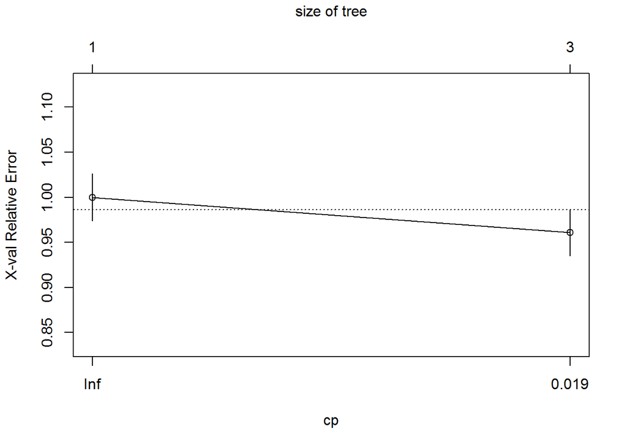

```r
library(rpart)
tree <- rpart(Esteem~LIncome2005+AFQT+Educ+Gender, data = trainesdata, method = "class")
plotcp(tree)
```

```r
pred <- rep("1",nrow(testesdata))
for (i in 1:nrow(testesdata))
if (testesdata$Educ[i]<13.5 && testesdata$AFQT[i]<18.2425)
pred[i] <- "0"
table(Predicted=pred,Original=testesdata$Esteem)
```

```
##          Original
## Predicted   0   1
##         0  38  21
##         1 171 285
```